# **KSU: Drivers of Fungal Community Dynamics**

Kelli Feeser

2024-03-12

[Back to Home](https://kellifeeser.github.io/ksu-paired-amplicon-workflow/index.html)

# 1 Map of sites and samples

## 1.1 Prior mislabeling of samples from ONF

The Kansas site ONF was labeled as ‘South Middle’ in factor ‘Bin’ in previous manuscripts. It should be ‘North’.

[interactive chart not shown]

Map of sites colored by latitudinal bin.

## 1.2 Mapping metadata

### 1.2.1 Combining lat and long

Coloring by both lat and long gradients

#### Map

[interactive chart not shown]

#### on a plot

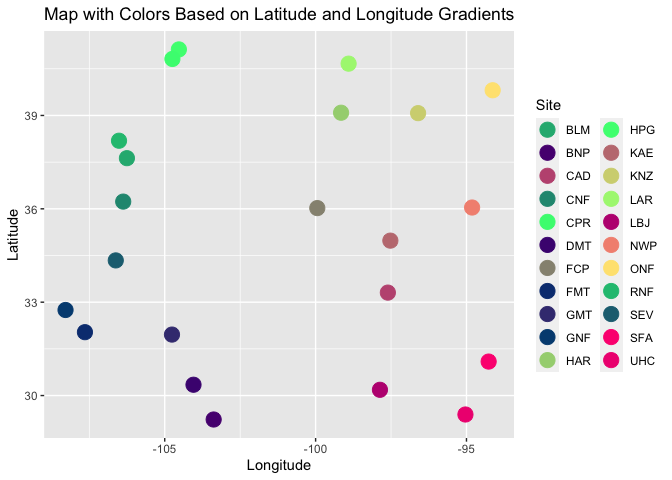

### 1.2.2 Edaphic

#### pH

[interactive chart not shown]

#### soil moisture

[interactive chart not shown]

#### SOM

[interactive chart not shown]

#### ammonium

[interactive chart not shown]

#### phosphorous

[interactive chart not shown]

### 1.2.3 Climate

#### Precipitation

ppt3yr = mean annual precipitation (determined over a 3-year window)

[interactive chart not shown]

#### Growing degree days

GDD3yr = growing degree days (determined over a 3-year window)

[interactive chart not shown]

### 1.2.4 Plant Traits

#### Specific root length

avg_SRL = specific root length

[interactive chart not shown]

#### Specific leaf area

avg_SLA = specific leaf area

[interactive chart not shown]

#### Herbivory percent

herbivory_perc = average site level damage estimate for herbivory, averaged over all species and individuals at the site; could be used to indicate herbivory pressure at the site level - ranges from 1:17 (%)

[interactive chart not shown]

### 1.2.5 Factors

#### Longitude (longitudinal ‘gradients’)

[interactive chart not shown]

# 2 Ordinations/NMDS

Ordination on the Gap Statistic

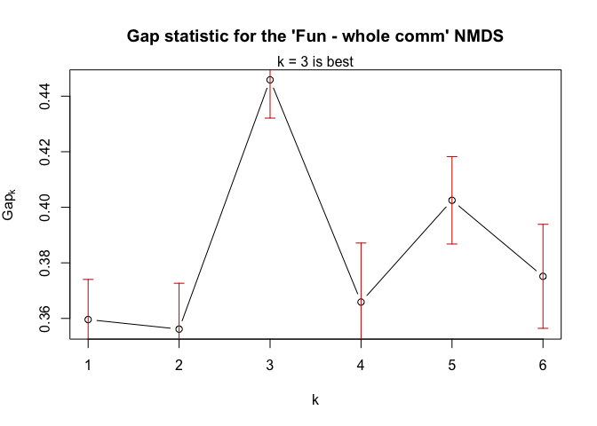

## 2.1 Lat/Long gradients

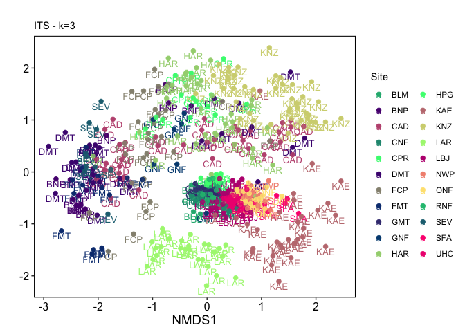

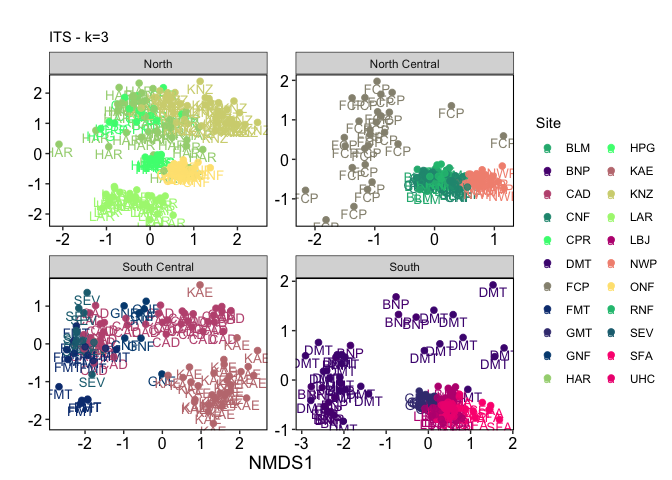

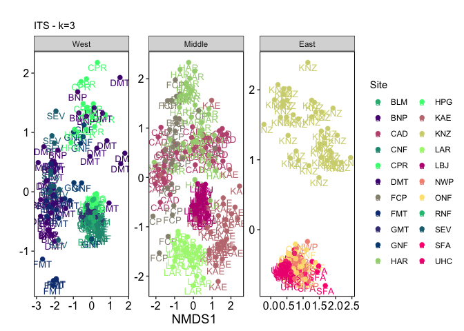

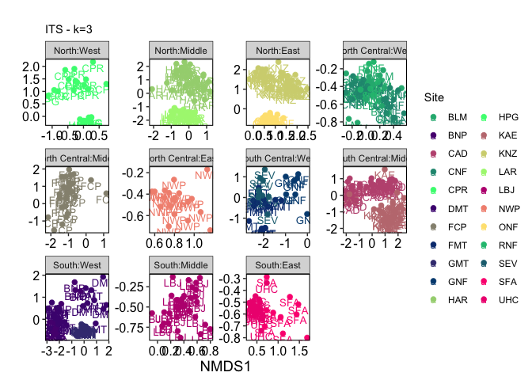

[interactive chart not shown]

# 3 Clustering (TBD)

When performing microbiome sample clustering, both model-based methods and machine learning methods have been used. Machine learning methods, which rely on defined distance metrics, are used more frequently than model-based statistical methods, due to their efficient implementation and easy interpretation. In this paper, we focused on the partition around medoids (PAM) [14] clustering method, which is related to but considered more robust than K-means. In contrast to K-means, which can be sensitive to the effects of outliers, PAM’s optimization goal is to minimize the sum of distances to the medoids instead of minimizing the sum of the squared distances to the cluster centers.

**Note: clustering was performed directly on distance matrices,** not **ordinations or ordination scores**

next: - bioenv

## 3.1 Gap Statistic (on distance matrix)

### view gap on bray

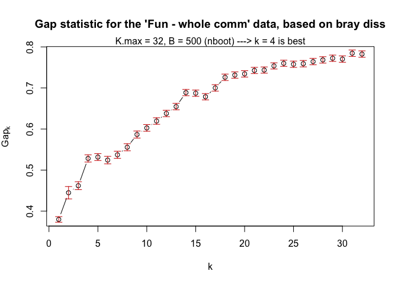

### view gap on sørensen

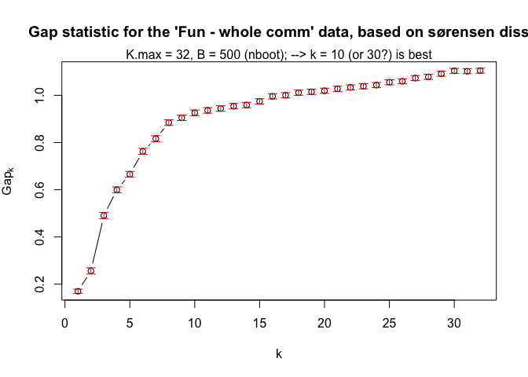

## 3.2 perform PAM

```r
# Perform PAM clustering
pam_fwc_bc_k4 <- pam(Fun_wc_bray_distmat, k = 4, diss = T, cluster.only = T)

pam_fwc_sor_k10 <- pam(Fun_wc_sorensen_distmat, k = 10, diss = T, cluster.only = T)
pam_fwc_sor_k30 <- pam(Fun_wc_sorensen_distmat, k = 30, diss = T, cluster.only = T)

saveRDS(pam_fwc_bc_k4, file = "../processed_data/clean_rds_saves/pam/pam_fwc_bc_k4.rds")
saveRDS(pam_fwc_sor_k10, file = "../processed_data/clean_rds_saves/pam/pam_fwc_sor_k10.rds")
saveRDS(pam_fwc_sor_k30, file = "../processed_data/clean_rds_saves/pam/pam_fwc_sor_k30.rds")
```

## 3.3 view clusters on NMDS

### Bray-Curtis

#### k = 4

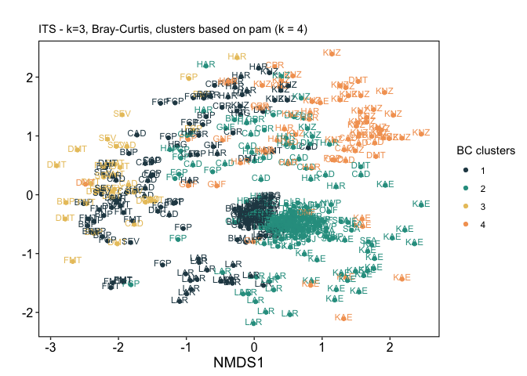

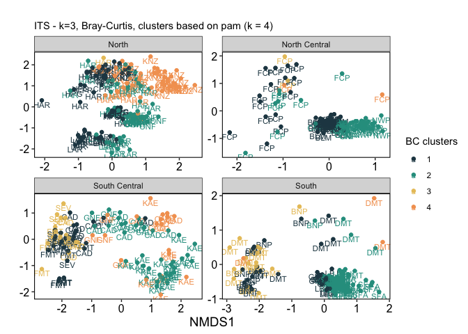

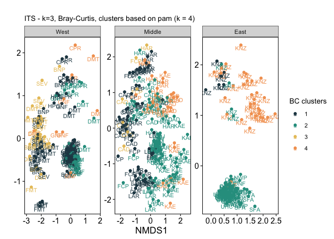

### Sørensen

#### k = 10

# in progress

## 3.4 all?

```r
# no facet

plot_ordination(Fun_wholecommunity, Fun_wholecommunity.k3.ord, color = "Gradient") +
  geom_text(mapping = aes(label = Site_Grass), size = 4, vjust = 1.5) +
  scale_color_manual(values = fun_grad_cols_n3
                     # ,name="Grass Host"
                     ) +
  geom_point(size = 3, alpha = 0.9) +
  labs(y="") +
  ggtitle("", subtitle = "ITS - k=3") +
  theme_bw() +
  theme(legend.position="right",
    axis.text.x = element_text(color="black", size=12),
    axis.text.y = element_text(color="black", size=12),
    axis.title.x = element_text(color="black", size=14),
    axis.title.y = element_text(color="black", size=14),
    plot.background = element_blank(),panel.border = element_rect(colour = "black", fill=NA, linewidth=.75),
    panel.grid.major = element_blank(),panel.grid.minor = element_blank(),panel.background = element_blank())

plot_ordination(Fun_wholecommunity, Fun_wholecommunity.k3.ord, color = "Bin") +
  geom_text(mapping = aes(label = Site_Grass), size = 4, vjust = 1.5) +
  scale_color_manual(values = fun_bin_cols_n5
                     # ,name="Grass Host"
                     ) +
  geom_point(size = 3, alpha = 0.9) +
  labs(y="") +
  ggtitle("", subtitle = "ITS - k=3") +
  theme_bw() +
  theme(legend.position="right",
    axis.text.x = element_text(color="black", size=12),
    axis.text.y = element_text(color="black", size=12),
    axis.title.x = element_text(color="black", size=14),
    axis.title.y = element_text(color="black", size=14),
    plot.background = element_blank(),panel.border = element_rect(colour = "black", fill=NA, linewidth=.75),
    panel.grid.major = element_blank(),panel.grid.minor = element_blank(),panel.background = element_blank())

plot_ordination(Fun_wholecommunity, Fun_wholecommunity.k3.ord, color = "Grass") +
  geom_text(mapping = aes(label = Site_Grass), size = 4, vjust = 1.5) +
  scale_color_manual(values = fun_grass_cols
                     # ,name="Grass Host"
                     ) +
  geom_point(size = 3, alpha = 0.9) +
  labs(y="") +
  ggtitle("", subtitle = "ITS - k=3") +
  theme_bw() +
  theme(legend.position="right",
    axis.text.x = element_text(color="black", size=12),
    axis.text.y = element_text(color="black", size=12),
    axis.title.x = element_text(color="black", size=14),
    axis.title.y = element_text(color="black", size=14),
    plot.background = element_blank(),panel.border = element_rect(colour = "black", fill=NA, linewidth=.75),
    panel.grid.major = element_blank(),panel.grid.minor = element_blank(),panel.background = element_blank())

# facet Grass
plot_ordination(Fun_wholecommunity, Fun_wholecommunity.k3.ord, color = "Gradient") +
  geom_text(mapping = aes(label = Site_Grass), size = 4.5, vjust = 1.5) +
  scale_color_manual(values = fun_grad_cols_n3
                     # ,name="Grass Host"
                     ) +
  geom_point(size = 3, alpha = 0.9) +
  facet_wrap(.~Grass, scales = "free") +
  labs(y="") +
  ggtitle("", subtitle = "ITS - k=3") +
  theme_bw() +
  theme(legend.position="right",
    axis.text.x = element_text(color="black", size=12),
    axis.text.y = element_text(color="black", size=12),
    axis.title.x = element_text(color="black", size=14),
    axis.title.y = element_text(color="black", size=14),
    plot.background = element_blank(),panel.border = element_rect(colour = "black", fill=NA, linewidth=.75),
    panel.grid.major = element_blank(),panel.grid.minor = element_blank(),panel.background = element_blank())

plot_ordination(Fun_wholecommunity, Fun_wholecommunity.k3.ord, color = "Bin") +
  geom_text(mapping = aes(label = Site_Grass), size = 4.5, vjust = 1.5) +
  scale_color_manual(values = fun_bin_cols_n5
                     # ,name="Grass Host"
                     ) +
  geom_point(size = 4, alpha = 0.9) +
  # scale_size_manual(values = c(3,6)) +
  facet_wrap(.~Grass, scales = "free") +
  labs(y="") +
  ggtitle("", subtitle = "ITS - k=3") +
  theme_bw() + #default is 11
  theme(legend.position="right",
    axis.text.x = element_text(color="black", size=12),
    axis.text.y = element_text(color="black", size=12),
    axis.title.x = element_text(color="black", size=14),
    axis.title.y = element_text(color="black", size=14),
    plot.background = element_blank(),panel.border = element_rect(colour = "black", fill=NA, linewidth=.75),
    panel.grid.major = element_blank(),panel.grid.minor = element_blank(),panel.background = element_blank())

# facet Bin
plot_ordination(Fun_wholecommunity, Fun_wholecommunity.k3.ord, color = "Grass") +
  geom_text(mapping = aes(label = Site), size = 4.5, vjust = 1.5) +
  scale_color_manual(values = fun_grass_cols
                     # ,name="Grass Host"
                     ) +
  geom_point(size = 3, alpha = 0.9) +
  facet_wrap(.~Bin, scales = "free") +
  labs(y="") +
  ggtitle("", subtitle = "ITS - k=3") +
  theme_bw() +
  theme(legend.position="right",
    axis.text.x = element_text(color="black", size=12),
    axis.text.y = element_text(color="black", size=12),
    axis.title.x = element_text(color="black", size=14),
    axis.title.y = element_text(color="black", size=14),
    plot.background = element_blank(),panel.border = element_rect(colour = "black", fill=NA, linewidth=.75),
    panel.grid.major = element_blank(),panel.grid.minor = element_blank(),panel.background = element_blank())
```

```r
# facet Bin*Gradient
plot_ordination(Fun_wholecommunity, Fun_wholecommunity.k3.ord, color = "Grass") +
  geom_text(mapping = aes(label = Site), size = 4.5, vjust = 1.5) +
  scale_color_manual(values = fun_grass_cols
                     # ,name="Grass Host"
                     ) +
  geom_point(size = 3, alpha = 0.9) +
  facet_wrap(.~Bin:Gradient) +
  labs(y="") +
  ggtitle("", subtitle = "ITS - k=3, scales=fixed") +
  theme_bw() +
  theme(legend.position="right",
    axis.text.x = element_text(color="black", size=12),
    axis.text.y = element_text(color="black", size=12),
    axis.title.x = element_text(color="black", size=14),
    axis.title.y = element_text(color="black", size=14),
    plot.background = element_blank(),panel.border = element_rect(colour = "black", fill=NA, linewidth=.75),
    panel.grid.major = element_blank(),panel.grid.minor = element_blank(),panel.background = element_blank())

plot_ordination(Fun_wholecommunity, Fun_wholecommunity.k3.ord, color = "Grass") +
  geom_text(mapping = aes(label = Site), size = 4, vjust = 1.5) +
  scale_color_manual(values = fun_grass_cols
                     # ,name="Grass Host"
                     ) +
  geom_point(size = 3, alpha = 0.9) +
  facet_wrap(.~Bin:Gradient, scales = "free") +
  labs(y="") +
  ggtitle("", subtitle = "ITS - k=3, scales=free") +
  theme_bw() +
  theme(legend.position="right",
    axis.text.x = element_text(color="black", size=12),
    axis.text.y = element_text(color="black", size=12),
    axis.title.x = element_text(color="black", size=14),
    axis.title.y = element_text(color="black", size=14),
    plot.background = element_blank(),panel.border = element_rect(colour = "black", fill=NA, linewidth=.75),
    panel.grid.major = element_blank(),panel.grid.minor = element_blank(),panel.background = element_blank())

adonis2(phyloseq::distance(Fun_wholecommunity, method="bray") ~ Site*Grass,
          data = (as(sample_data(Fun_wholecommunity), "data.frame")))
```

## 3.5 long

```r
plot_ordination(Fun_wholecommunity, Fun_wholecommunity.k3.ord, color = "Gradient", label = "Grass") +
  scale_color_manual(values = fun_grad_cols_n3
                     # ,name="Grass Host"
                     ) +
  geom_point(size = 3, alpha = 0.9) +
  labs(y="") +
  ggtitle("", subtitle = "ITS - k=3") +
  theme_bw() +
  theme(legend.position="right",
    axis.text.x = element_text(color="black", size=12),
    axis.text.y = element_text(color="black", size=12),
    axis.title.x = element_text(color="black", size=14),
    axis.title.y = element_text(color="black", size=14),
    plot.background = element_blank(),panel.border = element_rect(colour = "black", fill=NA, linewidth=.75),
    panel.grid.major = element_blank(),panel.grid.minor = element_blank(),panel.background = element_blank())

plot_ordination(Fun_wholecommunity, Fun_wholecommunity.k5.ord, color = "Gradient", label = "Grass") +
  scale_color_manual(values = fun_grad_cols_n3
                     # ,name="Grass Host"
                     ) +
  geom_point(size = 3, alpha = 0.9) +
  labs(y="") +
  ggtitle("", subtitle = "ITS - k=5") +
  theme_bw() +
  theme(legend.position="right",
    axis.text.x = element_text(color="black", size=12),
    axis.text.y = element_text(color="black", size=12),
    axis.title.x = element_text(color="black", size=14),
    axis.title.y = element_text(color="black", size=14),
    plot.background = element_blank(),panel.border = element_rect(colour = "black", fill=NA, linewidth=.75),
    panel.grid.major = element_blank(),panel.grid.minor = element_blank(),panel.background = element_blank())
```

```r
plot_ordination(Fun_wholecommunity, Fun_wholecommunity.k3.ord, color = "Gradient", label = "Site") +
  scale_color_manual(values = fun_grad_cols_n3
                     # ,name="Grass Host"
                     ) +
  geom_point(size = 3, alpha = 0.9) +
  facet_wrap(.~Grass) +
  labs(y="") +
  ggtitle("", subtitle = "ITS - k=3") +
  theme_bw() +
  theme(legend.position="right",
    axis.text.x = element_text(color="black", size=12),
    axis.text.y = element_text(color="black", size=12),
    axis.title.x = element_text(color="black", size=14),
    axis.title.y = element_text(color="black", size=14),
    plot.background = element_blank(),panel.border = element_rect(colour = "black", fill=NA, linewidth=.75),
    panel.grid.major = element_blank(),panel.grid.minor = element_blank(),panel.background = element_blank())

plot_ordination(Fun_wholecommunity, Fun_wholecommunity.k5.ord, color = "Gradient", label = "Site") +
  scale_color_manual(values = fun_grad_cols_n3
                     # ,name="Grass Host"
                     ) +
  geom_point(size = 3, alpha = 0.9) +
  facet_wrap(.~Grass) +
  labs(y="") +
  ggtitle("", subtitle = "ITS - k=5") +
  theme_bw() +
  theme(legend.position="right",
    axis.text.x = element_text(color="black", size=12),
    axis.text.y = element_text(color="black", size=12),
    axis.title.x = element_text(color="black", size=14),
    axis.title.y = element_text(color="black", size=14),
    plot.background = element_blank(),panel.border = element_rect(colour = "black", fill=NA, linewidth=.75),
    panel.grid.major = element_blank(),panel.grid.minor = element_blank(),panel.background = element_blank())
```

## 3.6 lat

```r
plot_ordination(Fun_wholecommunity, Fun_wholecommunity.k3.ord, color = "Bin", label = "Grass") +
  scale_color_manual(values = fun_bin_cols_n5
                     # ,name="Grass Host"
                     ) +
  geom_point(size = 3, alpha = 0.9) +
  labs(y="") +
  ggtitle("", subtitle = "ITS - k=3") +
  theme_bw() +
  theme(legend.position="right",
    axis.text.x = element_text(color="black", size=12),
    axis.text.y = element_text(color="black", size=12),
    axis.title.x = element_text(color="black", size=14),
    axis.title.y = element_text(color="black", size=14),
    plot.background = element_blank(),panel.border = element_rect(colour = "black", fill=NA, linewidth=.75),
    panel.grid.major = element_blank(),panel.grid.minor = element_blank(),panel.background = element_blank())

plot_ordination(Fun_wholecommunity, Fun_wholecommunity.k5.ord, color = "Bin", label = "Grass") +
  scale_color_manual(values = fun_bin_cols_n5
                     # ,name="Grass Host"
                     ) +
  geom_point(size = 3, alpha = 0.9) +
  labs(y="") +
  ggtitle("", subtitle = "ITS - k=5") +
  theme_bw() +
  theme(legend.position="right",
    axis.text.x = element_text(color="black", size=12),
    axis.text.y = element_text(color="black", size=12),
    axis.title.x = element_text(color="black", size=14),
    axis.title.y = element_text(color="black", size=14),
    plot.background = element_blank(),panel.border = element_rect(colour = "black", fill=NA, linewidth=.75),
    panel.grid.major = element_blank(),panel.grid.minor = element_blank(),panel.background = element_blank())
```

```r
plot_ordination(Fun_wholecommunity, Fun_wholecommunity.k3.ord, color = "Bin") +
  geom_text(mapping = aes(label = Site), size = 5, vjust = 1.5) +
  scale_color_manual(values = fun_bin_cols_n5
                     # ,name="Grass Host"
                     ) +
  geom_point(size = 4, alpha = 0.9) +
  # scale_size_manual(values = c(3,6)) +
  facet_wrap(.~Grass, scales = "free") +
  labs(y="") +
  ggtitle("", subtitle = "ITS - k=3") +
  theme_bw() + #default is 11
  theme(legend.position="right",
    axis.text.x = element_text(color="black", size=12),
    axis.text.y = element_text(color="black", size=12),
    axis.title.x = element_text(color="black", size=14),
    axis.title.y = element_text(color="black", size=14),
    plot.background = element_blank(),panel.border = element_rect(colour = "black", fill=NA, linewidth=.75),
    panel.grid.major = element_blank(),panel.grid.minor = element_blank(),panel.background = element_blank())

plot_ordination(Fun_wholecommunity, Fun_wholecommunity.k5.ord, color = "Bin") +
  geom_text(mapping = aes(label = Site), size = 5, vjust = 1.5) +
  scale_color_manual(values = fun_bin_cols_n5
                     # ,name="Grass Host"
                     ) +
  geom_point(size = 4, alpha = 0.9) +
  facet_wrap(.~Grass, scales = "free") +
  labs(y="") +
  ggtitle("", subtitle = "ITS - k=5") +
  theme_bw() + #default is 11
  theme(legend.position="right",
    axis.text.x = element_text(color="black", size=12),
    axis.text.y = element_text(color="black", size=12),
    axis.title.x = element_text(color="black", size=14),
    axis.title.y = element_text(color="black", size=14),
    plot.background = element_blank(),panel.border = element_rect(colour = "black", fill=NA, linewidth=.75),
    panel.grid.major = element_blank(),panel.grid.minor = element_blank(),panel.background = element_blank())
```